# Final Report – Predicting Made and Missed Shots in the NBA

Andrew Fenichel

I joined two data sets in order to do this project – one data set that includes every single shot attempt form the 2015 NBA season (which includes my response variable `fgm`, a binary varaible in which 1 = a made shot and 0 = a missed shot) and another data set of NBA player statistics for the purpose of predictor variables, including offensive and defensive efficiency statistics.

**Glimpse of data set**

```
##   closest_defender         player_name final_margin shot_number period
## 1     Aaron Brooks          chris paul           10          12      3
## 3     Aaron Brooks        jared dudley           -8           8      4
## 4     Aaron Brooks        kyrie irving           14          15      4
## 5     Aaron Brooks       arron afflalo           -5          12      4
## 6     Aaron Brooks        jarrett jack           14           5      1
## 7     Aaron Brooks matthew dellavedova            6           3      4
##   game_clock shot_clock dribbles touch_time shot_dist pts_type shot_result
## 1   11:11:00       12.4        3        2.4      17.7        2      missed
## 3   10:02:00        9.4        3        3.4       6.9        2      missed
## 4   04:42:00        6.4        9        8.7      19.8        2      missed
## 5   02:05:00       12.0        0        1.1      25.5        3        made
## 6   01:53:00        7.7       10        9.7       8.7        2        made
## 7   11:11:00       22.6        0        0.8      25.1        3      missed
```

The first couple of models I trained performed poorly. I trained a linear model and a logistic model, and the linear model has an R^2 value of 0.00126 and the logistic model has a 0.608 test accuracy.

**Simple linear model with dribbles and closest defender distance as predictors**

```
## # A tibble: 1 x 11
##   r.squared adj.r.squared sigma statistic  p.value    df  logLik    AIC    BIC
##       <dbl>         <dbl> <dbl>     <dbl>    <dbl> <int>   <dbl>  <dbl>  <dbl>
## 1   0.00126       0.00125 0.498      67.0 8.68e-30     3 -76298. 1.53e5 1.53e5
## # … with 2 more variables: deviance <dbl>, df.residual <int>
```

```
## [1] 0.2479131
```

**Logistic model with closest defender distance, shot distance, touch time, shot clock time remaining, dbpm, and efg% as predictors**

```
## # A tibble: 7 x 5
##   term           estimate std.error statistic   p.value
##   <chr>             <dbl>     <dbl>     <dbl>     <dbl>
## 1 (Intercept)     -1.01     0.127       -7.98 1.44e- 15
## 2 close_def_dist   0.103    0.00352     29.3  2.22e-188
## 3 shot_dist       -0.0618   0.00109    -56.5  0.
## 4 touch_time      -0.0281   0.00263    -10.7  1.10e- 26
## 5 shot_clock       0.0148   0.00132     11.2  4.38e- 29
## 6 dbpm            -0.0640   0.00430    -14.9  3.99e- 50
## 7 nba_efgpct       2.27     0.243        9.33 1.03e- 20
```

```
## # A tibble: 4 x 4
##     fgm train_direction     n  prop
##   <dbl>           <dbl> <int> <dbl>
## 1     1               0 19173 0.242
## 2     1               1 17166 0.216
## 3     0               0 30756 0.388
## 4     0               1 12205 0.154
```

```
## # A tibble: 1 x 2
##   test_accuracy test_error
##           <dbl>      <dbl>
## 1         0.608      0.392
```

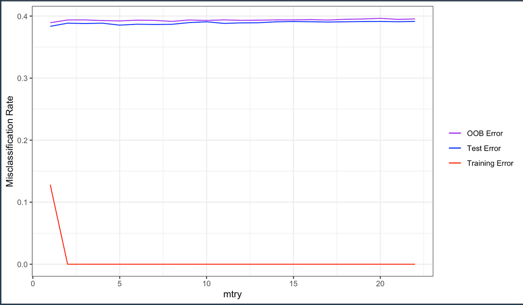

Random Forest Error Plot

Finally, I trained six different classes of boosted models, varying the `depth` and `nrounds` tuning parameters each time, until I landed on my best model, a boosted model with depth = 5, nrounds = 50, and a learning rate of 0.08.

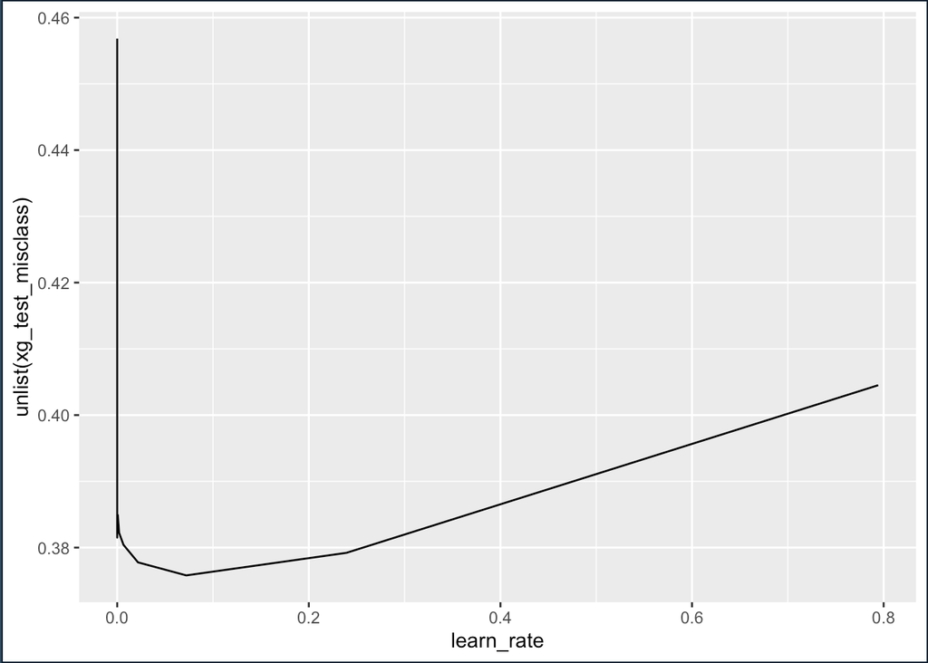

Boosted Model Learning Rate Plot

Also of note, a simple bar plot of variable importance shows that ten most “important” predictors are shot distance, closest defender distance, touch time, shot clock time remaining, closest defender block percentage, three point shooting percentage, player ID, defensive box plus minus, effective field goal percentage, and game clock time remaining.

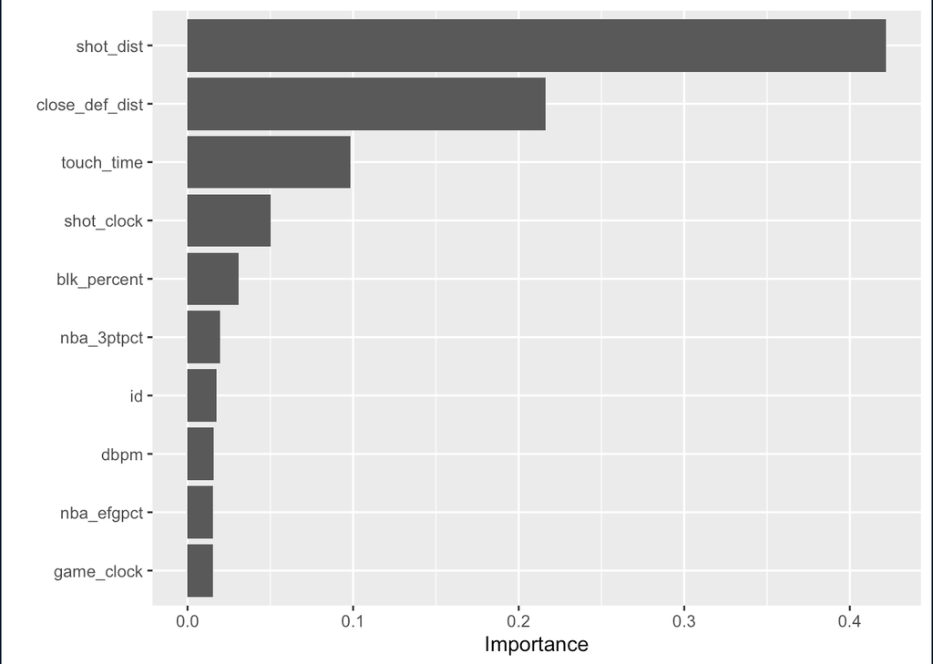

Boosted Model Variable Importance Plot

This final boosted model has the lowest misclass error (0.3758039) and therefore best test accuracy (0.6241961) of all the models I trained, so that is how I decided on using it as my final model.

My final model proves that shot selection (distance from the hoop and how open the offensive player is) matters more than defender defensive ability when it comes to making versus missing a shot–which is good to know when designing basketball offensive game plans.

My next possible steps include training even more complex and sophisticated models in order to improve my prediction ability even more, and then going back into the data and using player tracking data to begin qualifying “good” and “bad” shots in the moment of the game, and what “better” shots were possibly available for the offensive player. This high-level analysis can eventually lead to the ability to quantify offensive decision making in the NBA, which will help GMs assemble winning rosters and make smarter decisions in free agency and the draft.